# Vertical integration: RNA + ADT + ATAC

Vertical integration combines modalities measured in the same cells. This tutorial is for RNA, surface protein and ATAC from the same cells. It runs Matilda and UINMF on `D22mini`, 3,000 cells of the benchmark dataset `D22`, and then on data in your own format.

Methods run on Linux. On macOS or Windows, [open this notebook in Colab](https://colab.research.google.com/github/DSichang/scMultiBench/blob/main/notebooks/tutorial_vertical_rna_adt_atac.ipynb).

## 1. Install

This cell installs `multibench-sc`. It keeps the numpy and pandas that are already installed, so Colab needs no restart.

**Details**

On Colab, choose a GPU runtime before you run the notebook: Runtime -> Change runtime type -> T4 GPU. On a CPU runtime, an environment that has a smaller CPU build gets that build, and training methods run slower.

```python
import numpy, pandas
pins = f"numpy=={numpy.__version__} pandas=={pandas.__version__}"
%pip install -q "multibench-sc>=0.4.0" {pins}
```

## 2. Download the data and the environments

`mtb.data.fetch` downloads `D22mini` (8 MB) once. Each method runs in its own environment. `mtb.env.install` downloads the environments for Matilda and UINMF, with no conda needed. The download is 1.5 GB on a computer without a GPU and 4.0 GB on one with a GPU.

**Details**

`state` is `PACKED` for an environment downloaded now and `have` for one that was already there. With `dry_run=True`, `mtb.env.install` downloads nothing and returns the plan with its sizes.

Environments go to `mtb.config.envs_dir`. To use another disk, set it before this cell.

```python
import pandas as pd
import multibench as mtb

mtb.data.fetch("D22mini")
```

```
downloading D22mini (8 MB) from https://github.com/DSichang/scMultiBench/releases/download/data-v1/D22mini.tar.gz ...
```

```
PosixPath('/tmp/mbtut_040/home/.cache/multibench/data/D22mini')
```

```python
METHODS = ["Matilda", "UINMF"]
envs = mtb.env.install(METHODS)
envs[["env", "methods", "state"]]
```

```
[env] downloading matilda (gpu build) 3.0 GB ...
```

[output not shown]

[output not shown]

[output not shown]

[output not shown]

[output not shown]

[output not shown]

[output not shown]

[output not shown]

[output not shown]

```
[env]   3.0 GB of 3.0 GB (96 MB/s)
```

```
[env] unpacking matilda -> /tmp/mbtut_040/home/.cache/multibench/envs/matilda ...
```

```
[env] downloading scmb_r (single build) 917 MB ...
```

```
[env]   connection lost (URLError); resuming
```

[output not shown]

[output not shown]

[output not shown]

[output not shown]

[output not shown]

[output not shown]

[output not shown]

[output not shown]

[output not shown]

```
[env]   917 MB of 917 MB (6 MB/s)
```

```
[env] unpacking scmb_r -> /tmp/mbtut_040/home/.cache/multibench/envs/scmb_r ...
```

|  | env | methods | state |
| --- | --- | --- | --- |
| 0 | matilda | [Matilda] | PACKED |
| 1 | scmb_r | [UINMF] | PACKED |

## 3. Run the methods

`run` runs each method on `D22mini` and scores its output with the scIB metrics. `res.summary` has one row per method with its status, run time and scores. Higher is better for every metric.

**Details**

Each method writes an embedding: a table of numbers with one row per cell. `run` scores it against the cell-type labels of `D22mini`.

The clustering metrics `ARI`, `NMI`, `ASW`, `iASW`, `iF1` and `cLISI` measure how well the embedding separates the cell types. The batch metrics `ASW_batch`, `ARI_batch`, `NMI_batch`, `GC` and `iLISI` measure how well the batches mix. They appear only when the data has several batches.

The `reason` column of `res.summary` says why a method failed. `params={"Method": {"key": value}}` sets a method's parameters, and `mtb.params_for` lists them. Many methods take none.

`mtb.load_run("out/D22mini")` reloads these results later without running anything.

```python
res = mtb.run("D22mini", "vertical", methods=METHODS,
                  out_dir="out/D22mini")
res.summary
```

```
[run] Matilda runs on rna+adt+atac, not on rna+adt and rna+atac, whose files are part of it. Pass modalities= to run a smaller combination.
```

```
[run] UINMF runs on rna+adt+atac, not on rna+adt and rna+atac, whose files are part of it. Pass modalities= to run a smaller combination.
```

```
[run] Matilda (vertical/D22mini) ...
```

```
Fetching the method scripts from PYangLab/scMultiBench into /tmp/mbtut_040/home/.cache/multibench/scMultiBench_ref ...
```

```
[run]   -> scored (19.9s) ARI 0.414
```

```
[run] UINMF (vertical/D22mini) ...
```

```
[run]   -> scored (18.6s) ARI 0.338
```

|  | method | status | ARI | NMI | ASW | iASW | iF1 | cLISI | run_sec | caveat | reason |
| --- | --- | --- | --- | --- | --- | --- | --- | --- | --- | --- | --- |
| 0 | Matilda | scored | 0.4137 | 0.7317 | 0.5706 | 0.5986 | 0.6832 | 0.9922 | 19.9 |  |  |
| 1 | UINMF | scored | 0.3380 | 0.6623 | 0.5672 | 0.5605 | 0.5282 | 0.9952 | 18.6 |  |  |

## 4. Plot

`res.plot()` draws the scores as a bubble table. Circle size shows the rank within a column, and bigger is better. The fill compares a value with the other rows in the same column.

**Details**

The lightest fill is the lowest value in this figure, not zero.

Metrics are grouped by family: blue for clustering, green for batch correction. Each family starts with an `Overall` bar. Its length and colour both show the family score.

A column whose rows all hold the same value is drawn grey, and a warning names it. A figure of one method is grey everywhere.

```python
res.plot()
```

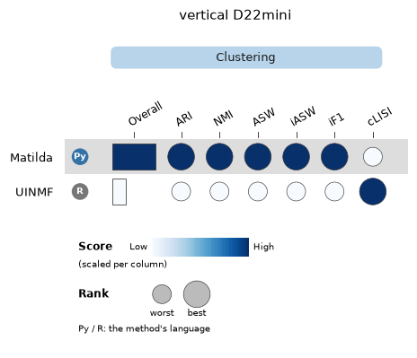

## 5. Your own data

Your data needs raw counts for RNA and protein (ADT) in one `.h5ad` file, an ATAC peak matrix of the same cells in another, and a cell type for each cell.

Several donors or samples in the file? Keep them in one folder, without `batch=` in `export_dataset`, and give `run` the column itself: `mtb.run(..., batch=adata.obs["donor"])`. The summary then has the scores for how well they mix.

Starting from something else? See the recipes for [a 10x `.h5` file](https://dsichang.github.io/scMultiBench/tutorials/run/#recipe-10x-h5), [labels in a CSV file](https://dsichang.github.io/scMultiBench/tutorials/run/#recipe-labels-csv), [no labels](https://dsichang.github.io/scMultiBench/tutorials/run/#recipe-no-labels) and [several donors or samples](https://dsichang.github.io/scMultiBench/tutorials/run/#recipe-donors).

**Details: export**

The names in quotes say where your file holds each part. `"X"` is the main matrix, `"obsm:protein"` the matrix `obsm["protein"]`, `"layer:counts"` the layer `layers["counts"]`, and `"obs:celltype"` the column `obs["celltype"]`, which `"celltype"` alone names too. A wrong name after `obsm:`, `layer:` or `obs:` raises an error that lists the names the file has.

The example keeps the protein names in `adata.uns["protein_names"]`. A DataFrame in `adata.obsm["protein"]` brings its own names in its columns.

The donors that `run` gets as `batch=` are matched to the cells by barcode, and every cell needs a donor. A column name alone is not enough there, because `run` reads the folder and the folder holds no `obs` columns.

`"mydata/" + NAME` is the dataset folder that `scan` and `run` read. With a new value of `NAME`, the folder holds the files of your data only.

The check lists the methods you name. Without `methods=`, it lists every method that reads the modalities in the folder. Its `command` column holds the line `run` would execute for each method.

`export_dataset` raises `FileExistsError` when the folder holds files of other cells that the call does not write. `overwrite=True` does not remove them. Give `NAME` a new value.

`overwrite=True` replaces the files of an earlier run of this cell. Without it, `export_dataset` raises `FileExistsError` rather than replace a file.

The cells below read your data, write it as a dataset folder, check the folder and run the same methods on it. So that the notebook runs as it is, the next cell writes two small example files, `my_file.h5ad` and `my_atac.h5ad`, from 60% of the cells of `D22mini`. It leaves a file of your own with one of those names as it is.

```python
mtb.data.write_example("D22mini")
```

```
wrote my_file.h5ad: 1,800 cells. RNA counts in X, protein counts in obsm["protein"], cell types in obs["celltype"].
```

```
wrote my_atac.h5ad: 1,800 cells. ATAC peak counts in X, cell types in obs["celltype"].
```

Read your files. For your own data, change every file name marked `# <-`. A name that you leave is read from the example. On Colab, upload the files first: click the folder icon on the left, then the upload icon. The cell reads `.h5ad` files. A 10x `.h5` file is read another way: see the recipe for a 10x `.h5` file, linked at the top of this section.

```python
import anndata as ad

adata = ad.read_h5ad("my_file.h5ad")   # <- your RNA and protein file
atac = ad.read_h5ad("my_atac.h5ad")    # <- your ATAC file, the same cells
print(adata)
print(atac)
```

```
AnnData object with n_obs × n_vars = 1800 × 1000
    obs: 'celltype'
    uns: 'protein_names'
    obsm: 'protein'
AnnData object with n_obs × n_vars = 1800 × 5000
    obs: 'celltype'
```

Write the dataset folder. Change each name in quotes marked `# <-`: give `NAME` a new value, and write the names that your files use for the other parts. The printout above lists the names in your files. Write a name listed after `obs:` with that prefix, as `"obs:celltype"`, and one after `obsm:` as `"obsm:protein"`.

```python
NAME = "MYTRI"   # <- a new name for your own data
mtb.io.export_dataset(adata, "mydata/" + NAME,
                      rna="X",                # <- where the RNA counts are
                      adt="obsm:protein",     # <- where the proteins (ADT) are
                      atac=atac,              # the ATAC file, peak counts in X
                      atac_kind="peak",       # the methods here read peaks
                      labels="obs:celltype",  # <- the cell-type column
                      overwrite=True)
```

```
PosixPath('mydata/MYTRI')
```

Check the folder before you run anything. `runnable` says whether a method can run on your data on this computer, and `reason` says why not. The first two lines above the table say what the folder holds and how many cells each file has. Compare them with your data. `atac.h5` and `atac_peak.h5` are one matrix under two names. A further line is about one method: why it cannot run, or what it does not read or needs from your data.

```python
mtb.scan("mydata/" + NAME, "vertical", methods=METHODS)
```

```
[scan] 2 of 2 methods have their input files in MYTRI. 2 of 2 can run on this computer. MYTRI holds RNA, ADT and ATAC.
```

```
[scan] Cells per file: rna.h5 1,800, adt.h5 1,800, atac.h5 1,800, atac_peak.h5 1,800.
```

|  | method | modalities | runnable | reason | env | caveat | command |
| --- | --- | --- | --- | --- | --- | --- | --- |
| 0 | Matilda | rna+adt+atac | True |  | matilda |  | bash -c 'export CONDA_PREFIX=/tmp/mbtut_040/ho... |
| 1 | UINMF | rna+adt+atac | True |  | scmb_r |  | bash -c 'export CONDA_PREFIX=/tmp/mbtut_040/ho... |

Run the same methods on the folder:

```python
mine = mtb.run("mydata/" + NAME, "vertical", methods=METHODS,
                   out_dir="out/" + NAME)
mine.summary
```

```
[run] Matilda runs on rna+adt+atac, not on rna+adt and rna+atac, whose files are part of it. Pass modalities= to run a smaller combination.
```

```
[run] UINMF runs on rna+adt+atac, not on rna+adt and rna+atac, whose files are part of it. Pass modalities= to run a smaller combination.
```

```
[run] Matilda (vertical/MYTRI) ...
```

```
[run]   -> scored (8.6s) ARI 0.358
```

```
[run] UINMF (vertical/MYTRI) ...
```

```
[run]   -> scored (15.9s) ARI 0.298
```

|  | method | status | ARI | NMI | ASW | iASW | iF1 | cLISI | run_sec | caveat | reason |
| --- | --- | --- | --- | --- | --- | --- | --- | --- | --- | --- | --- |
| 0 | Matilda | scored | 0.3585 | 0.7115 | 0.5655 | 0.5925 | 0.6477 | 0.9881 | 8.6 |  |  |
| 1 | UINMF | scored | 0.2984 | 0.6480 | 0.5838 | 0.5884 | 0.5330 | 0.9902 | 15.9 |  |  |

```python
mine.plot()
```

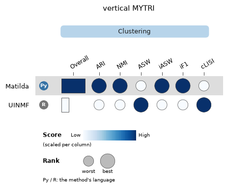

## 6. Every method of this task

5 methods have a variant for vertical RNA + ADT + ATAC. Each ran on `D22mini` in the package's own check, on a server with a GPU:

| Method | Result | Seconds |
| --- | --- | --- |
| MOFA2 | scored | 40 |
| Matilda | scored | 16 |
| Multigrate | scored | 48 |
| UINMF | scored | 20 |
| scMoMaT | scored on the UMAP it writes | 64 |

To run them all, set `METHODS` to these names in section 2 and run the notebook again. That downloads 5 envs, 16.4 GB to download on a CPU host, 18.5 GB on a GPU host. [This notebook](https://colab.research.google.com/github/DSichang/scMultiBench/blob/main/notebooks/tutorial_vertical_rna_adt_atac_all.ipynb) does the same in Colab.

## Troubleshooting

`res.summary[res.summary.status != "scored"]` lists each method that failed or was skipped. Its `reason` column ends with the method's error output.

**Details**

| symptom | fix |
| --- | --- |
| `env.install` refuses on macOS or Windows | methods run only on Linux: use Colab or a Linux machine |
| a method needs an NVIDIA GPU | choose a GPU runtime on Colab, or a machine with a GPU |
| a method fails on a small dataset | `mtb.scan` names what the method needs from the data's size in its `caveat` column |
| a warning that values are not whole numbers | export raw counts, for example with `rna="layer:counts"` |
| `... matrix/data as cells x features` | the matrix is transposed: export it again with `mtb.io.export_dataset` |
| a method times out | raise `timeout=` in `run` |
| batch metrics use the wrong batches | `res.rescore(batch=my_vector)` scores again without running the methods |

## Next steps

- The other tutorials: [vertical RNA + ADT](https://dsichang.github.io/scMultiBench/tutorials/vertical_rna_adt/), [vertical RNA + ATAC](https://dsichang.github.io/scMultiBench/tutorials/vertical_rna_atac/), [diagonal [RNA, ATAC]](https://dsichang.github.io/scMultiBench/tutorials/diagonal_rna_atac/), [diagonal [multiple RNA, multiple ATAC]](https://dsichang.github.io/scMultiBench/tutorials/diagonal_multi/), [mosaic [RNA, RNA + ADT, ADT]](https://dsichang.github.io/scMultiBench/tutorials/mosaic_rna_adt/), [mosaic [RNA, RNA + ATAC, ATAC]](https://dsichang.github.io/scMultiBench/tutorials/mosaic_rna_atac/), [mosaic Mixed, with shared modality](https://dsichang.github.io/scMultiBench/tutorials/mosaic_shared/), [mosaic Mixed, without shared modality](https://dsichang.github.io/scMultiBench/tutorials/mosaic_unshared/), [cross Multiple RNA + ADT](https://dsichang.github.io/scMultiBench/tutorials/cross_rna_adt/), [cross Multiple RNA + ATAC](https://dsichang.github.io/scMultiBench/tutorials/cross_rna_atac/), [cross Multiple ADT + ATAC](https://dsichang.github.io/scMultiBench/tutorials/cross_adt_atac/), [cross Multiple RNA + ADT + ATAC](https://dsichang.github.io/scMultiBench/tutorials/cross_rna_adt_atac/).
- The guides: [run](https://dsichang.github.io/scMultiBench/tutorials/run/), [evaluate](https://dsichang.github.io/scMultiBench/tutorials/evaluate/), [plot](https://dsichang.github.io/scMultiBench/tutorials/plot/) and [discover methods](https://dsichang.github.io/scMultiBench/tutorials/discover/).
- The [interactive explorer](https://shiny.maths.usyd.edu.au/scMultiBench/) has the full benchmark's rankings, with no install needed.